# NTOLab14

NTO

4/23/2019

### Overall questions and Importance:

- “Do mothers’ smoking habits affect the presence of premature births?” and “Do mothers’ smoking habits affect the correlation between their babys’ gestational age and birth weight?”
- These questions are important because answering them will allow us to provide recommendations to mothers on whether or not smoking is hurtful for their newborn babies. Most parents care deeply about the well-being of their babies, who contain fragile health, making this statistical study very relevant and important.

### Team Section

```
##
## Call:
## lm(formula = bwtoz ~ gestation, data = df)
##
## Coefficients:
## (Intercept)    gestation
##     37.3716       0.3033
```

```
##
## Call:
## lm(formula = bwtoz ~ gestation, data = df)
##
## Coefficients:
## (Intercept)    gestation
##    -58.9191       0.6212
```

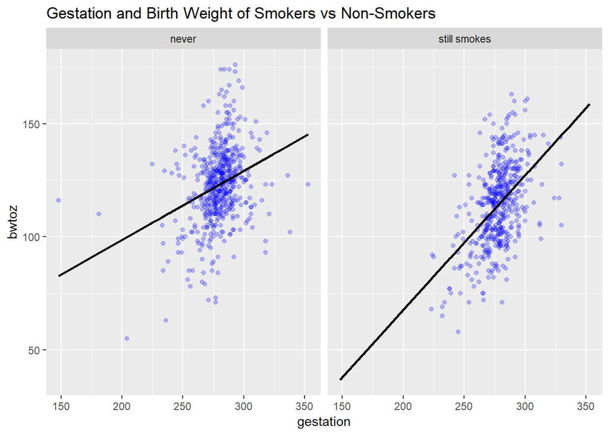

### David’s Section

Subquestion and Importance: Is there a coorelation between gestation and birthweight? Are ther other underlying facors that effect this coorelation?

This question is important to address because typically a premature babies are charachterized by a low gestation periods and premature babies usually weight less. If there are other factors that effect this coorelation, it can give us insight on what other variables have an effect on prematureness.

```
## (Intercept)   gestation
##  -5.9784357   0.4474284
```

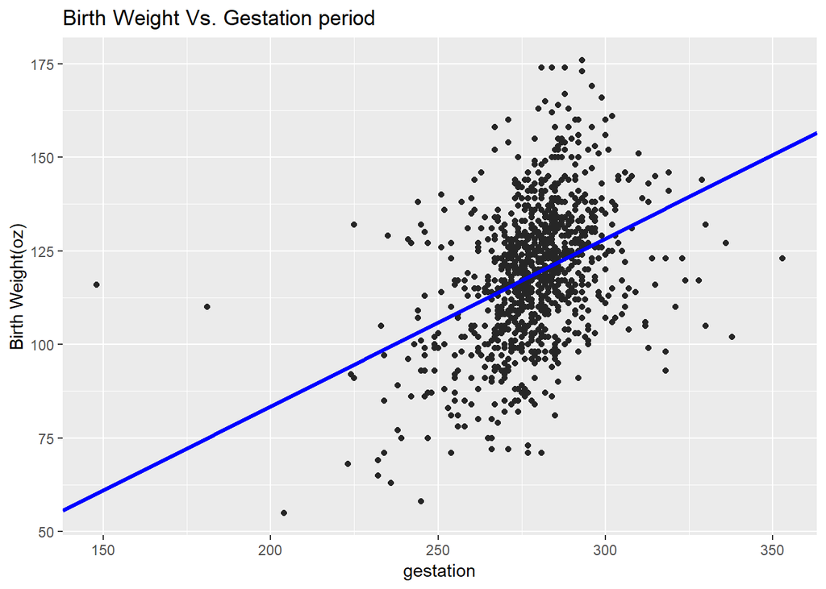

I used `lm()` to find the coeffients for the line a best fit using the model `a[1]+data* a[2]`. The intercept and slope are shown in the tibble above. The graph shows a positive trend between gestation and birthweight. The lower the gestation period the lower the birthweight.

How does a mother’s smoking habits influence this coorelation??

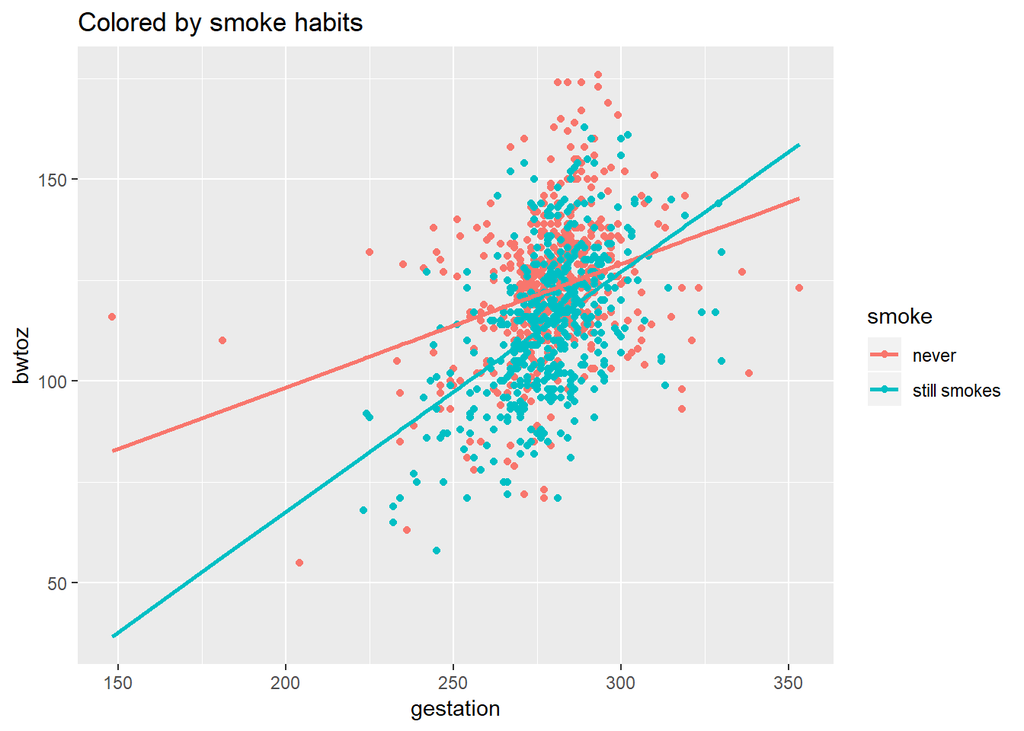

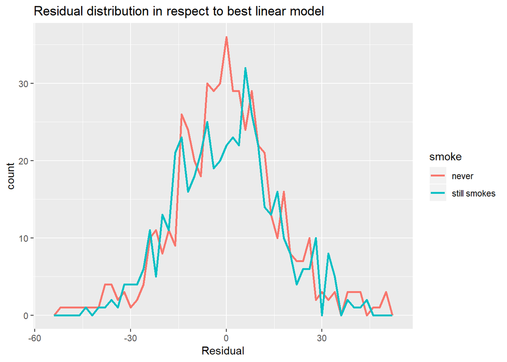

I used `add_residuals()` along with my model to plot the distribution of the redisuals in respect to the best linear model. The residial distributions are centered around zero which shows that the lines of best fit are accurate. The highest residual spike for mothers who still smoke as a higher residual. This makes sense if you consider the increased slope for the previous graph.

### Ryan’s Section

Subquestion and Importance: Age and weight on gestation, given premature. we know that smoking causes premature babies, but what about the mother’s age and weight, and how do they compare between smokers and non smokers?

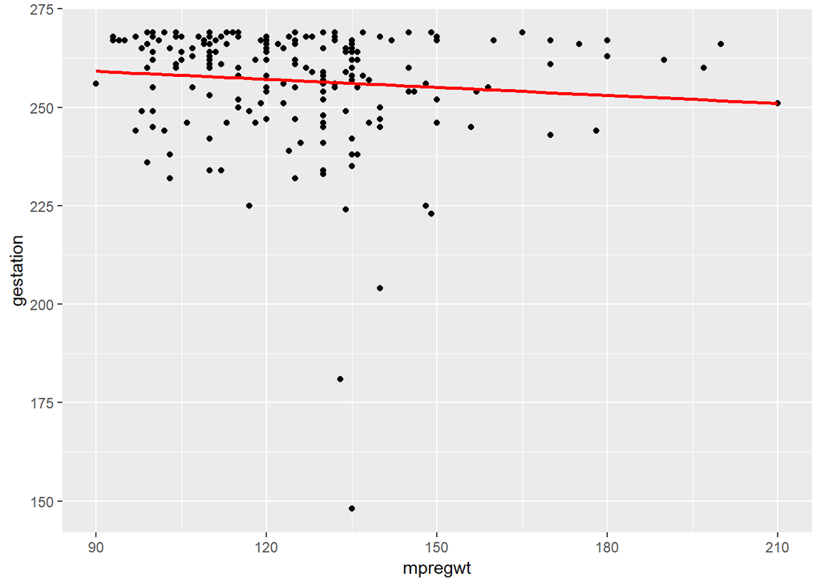

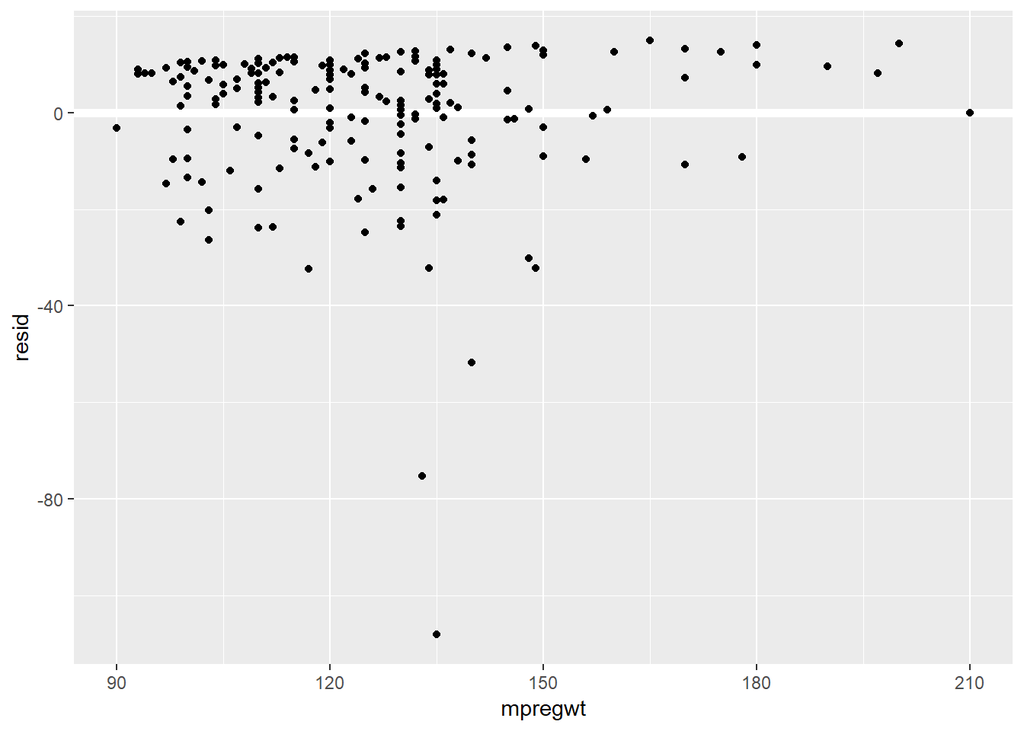

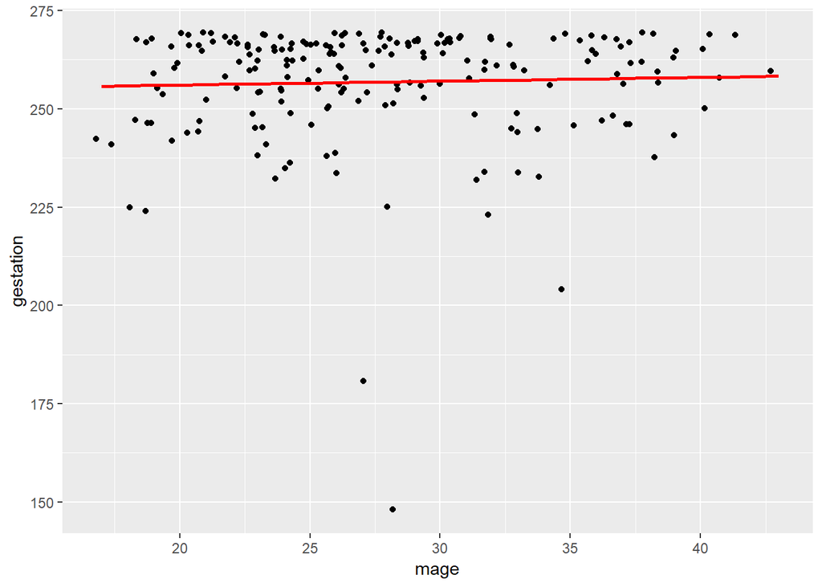

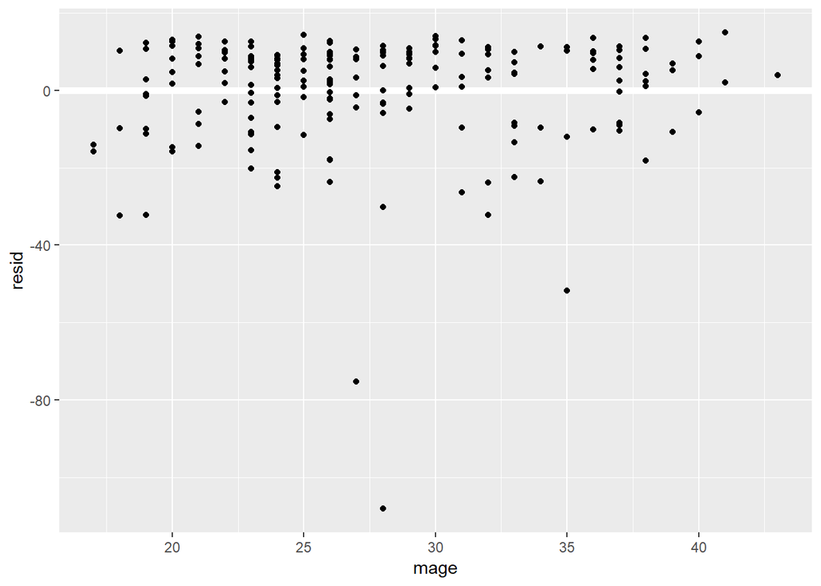

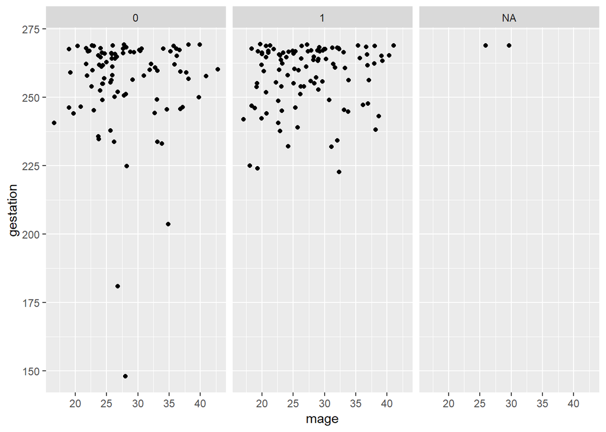

New Tools: grid, add_residuals, add predictions, coef, lm

Findings / Relation to Team Section: yeah so not much of a correlation for either age or mother’s weight.

### Ethan’s Section

Subquestion and Importance: Does a mother’s pregancy weight correlate with the baby’s birth weight and is this correlation affected by smoking habits? This question is important because I can make suggestions to mothers on how to improve health of babies if a correlation exists between these variables.

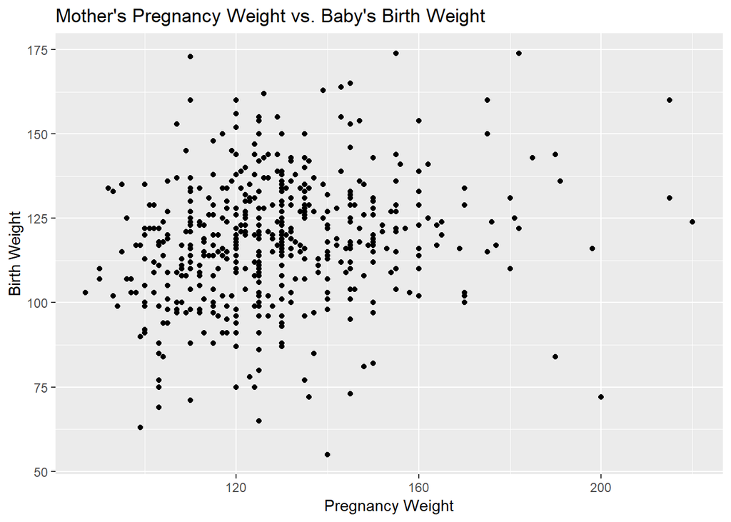

```
## (Intercept)     mpregwt
##  95.6354126   0.1773394
```

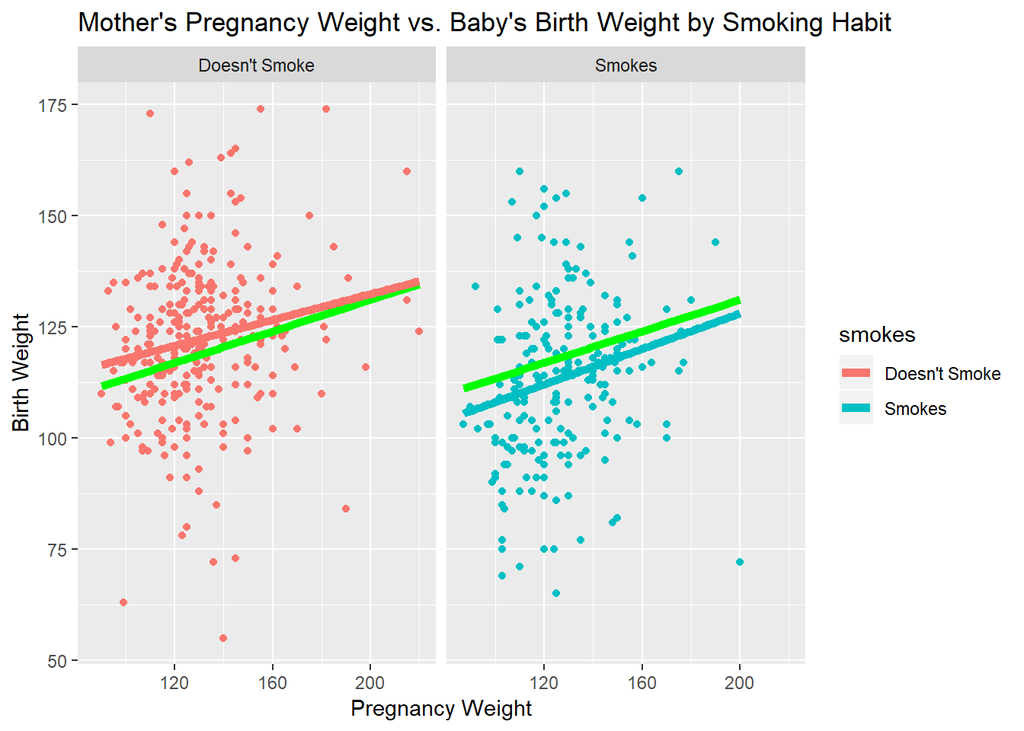

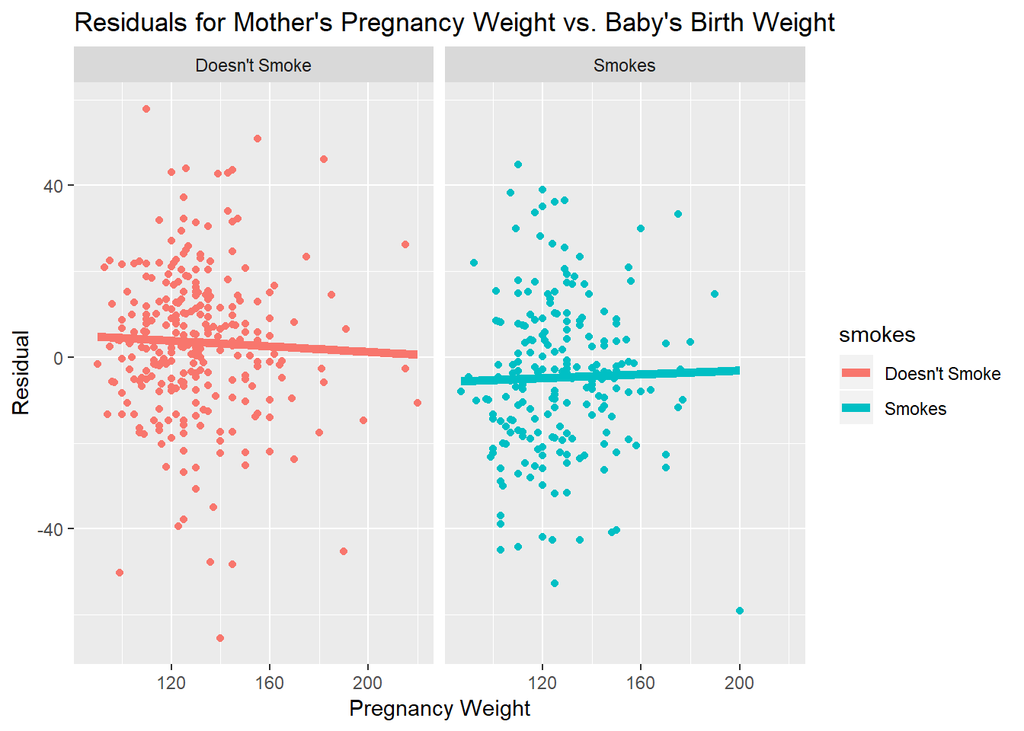

```
##
## Call:
## lm(formula = bwtoz ~ mpregwt, data = df)
##
## Coefficients:
## (Intercept)      mpregwt
##     103.366        0.145
```

```
##
## Call:
## lm(formula = bwtoz ~ mpregwt, data = df)
##
## Coefficients:
## (Intercept)      mpregwt
##     88.1345       0.1993
```

New Tools: I used nesting to group by smoking habits and get list columns, models, predictions, and residuals for both habits. I also used lm(), data_grid(), add_predictions(), and add_residuals() to make my basic models.

### Arie’s Section

Subquestion and Importance: How does smoking affect the pregnancy weight of moms? This question is important and interesting because children are the most fragile when they are in the whom. It is crucial for Mom’s to be cautious of what they do while carrying since it will have a direct affect to the unborn child.

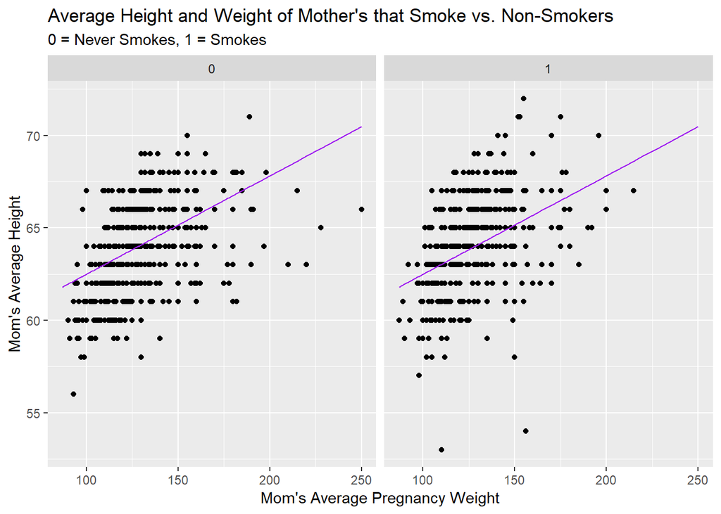

New Tools: I used `lm()`, `data_grid()`, `add_predictions` to create my linear model ontop of the original data.

Findings / Relation to Team Section: I found that there is a weak positive correlection of .4 between the mothers height and pregnancy weight. The data also shows that smoking has little to no effect on the mothers pregnancy weight.